# Unsupervised Learning: Principal Components

## Supervised vs Unsupervised

Methods so far focused on supervised learning

Now we'll look at some common unsupervised techniques

- Principal Components Analysis (PCA)
  - PCA Regression
- Clustering
  - K Means
  - Heirarchical

## Unsupervised Learning

Note: No great way to *check* results of your model

- There is no correct answer to look at with test data
- Hope that patterns detected extend to future data but checking that is difficult
- Overall, pretty subjective and generally considered exploratory
- Don't make really important decisions unless you can find a way to verify results extend!

## Principal Components

- Principal Components Analysis (PCA) is a dimension reduction technique
- If you have \(p\) variables, they contain some joint variability/correlation
- PCA looks for *linear combinations* of those \(p\) variables that account for most of the variability
- Usually can represent variability of the \(p\) variables by \(m<p\) PCs
- Reduces # of variables from \(p\) to \(m\)
- Can be useful for visualizations
- Can use PCs as predictors in a regression model (PC Regression)

## Principal Components

Let's visualize the idea in two dimensions.

```r
countyData <- read_csv("../datasets/counties.csv")
countyData
```

```
## # A tibble: 3,141 x 20
##   region county state   msa  pmsa pop.density   pop pop.change age6574
##   <chr>  <chr>  <chr> <int> <int>       <int> <int>      <dbl>   <dbl>
## 1 South  Autau~ AL     5240    NA          61 34222      11.9     5.70
## 2 South  Baldw~ AL     5160    NA          67 98280      35.4     9.20
## 3 South  Barbo~ AL       NA    NA          29 25417       2       8.20
## 4 South  Bibb   AL       NA    NA          28 16576       9.20    6.70
## 5 South  Blount AL     1000    NA          62 39248      10.6     7.40
## # ... with 3,136 more rows, and 11 more variables: age75 <dbl>,
## #   crime <int>, college <dbl>, income <int>, farm <dbl>, democrat <dbl>,
## #   republican <dbl>, Perot <dbl>, white <dbl>, black <dbl>, turnout <dbl>
```

## Consdier Income and Crime variables

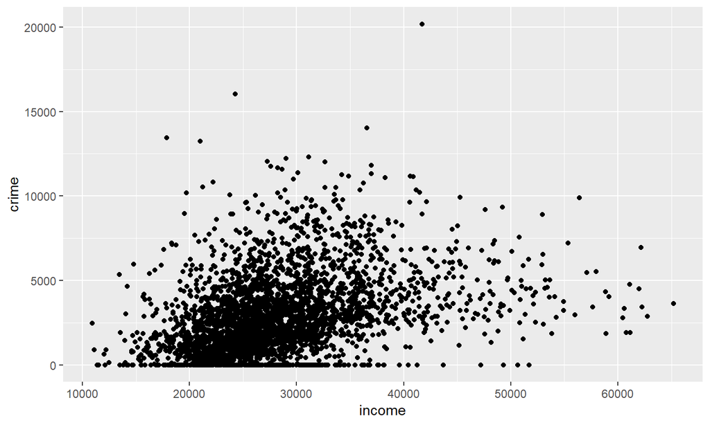

## Finding PCs in R

- Output will make more sense later!

```r
PCs <- prcomp(select(countyData, income, crime) , scale = TRUE)
PCs
```

```
## Standard deviations (1, .., p=2):
## [1] 1.155434 0.815458
##
## Rotation (n x k) = (2 x 2):
##               PC1        PC2
## income -0.7071068  0.7071068
## crime  -0.7071068 -0.7071068
```

## Biplot - Visual for PCA

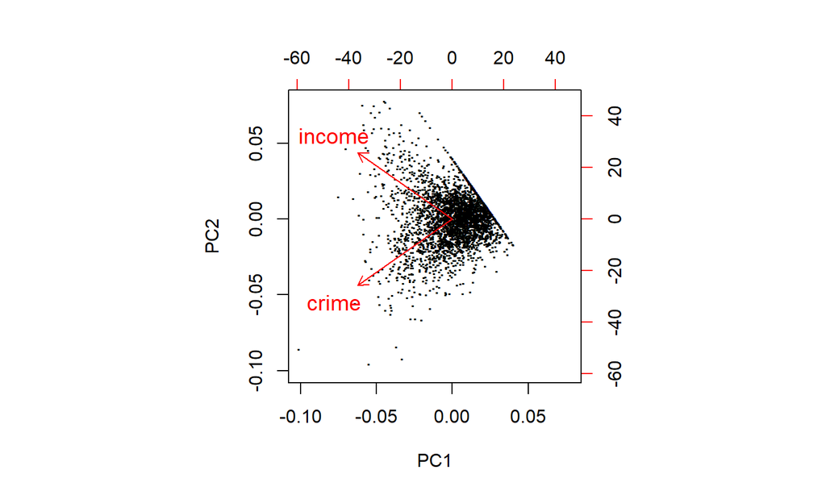

```r
biplot(PCs, xlabs = rep(".", nrow(countyData)), cex = 1.2)
```

## PCA with More Variables

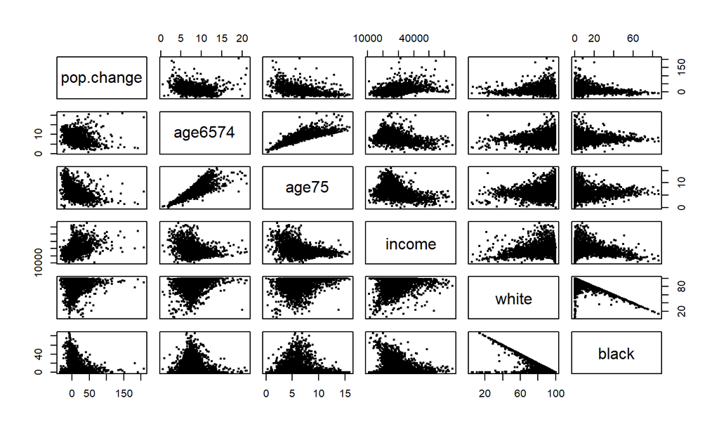

```r
subCountyData <- select(countyData, pop.change:age75, income, white, black) %>%
    `[`(rowSums(is.na(.)) == 0, )
pairs(subCountyData, cex = 0.4) #numeric vars only, remove nas
```

## PCA with More Variables

```r
PCs <- prcomp(subCountyData, center = TRUE, scale = TRUE)
PCs
```

```
## Standard deviations (1, .., p=6):
## [1] 1.6025670 1.3659474 0.8493128 0.7462012 0.4045648 0.3523432
##
## Rotation (n x k) = (6 x 6):
##                   PC1         PC2        PC3         PC4           PC5
## pop.change -0.3871942  0.23586385 -0.7348314  0.45628706 -0.0009506493
## age6574     0.5327883 -0.06625251 -0.5363113 -0.07452922  0.0801851487
## age75       0.5717587 -0.07693114 -0.2635841 -0.23015097 -0.2332104031
## income     -0.3401538  0.39747879 -0.2175688 -0.81778137 -0.0833688626
## white       0.2810171  0.61146690  0.1288379  0.06349392  0.7111870516
## black      -0.2112678 -0.63417608 -0.1974361 -0.24592723  0.6530275311
##                    PC6
## pop.change  0.21511141
## age6574    -0.64197601
## age75       0.70024313
## income     -0.05703581
## white       0.14394411
## black       0.16516795
```

## Variability with Fewer (Uncorrelated) Variables

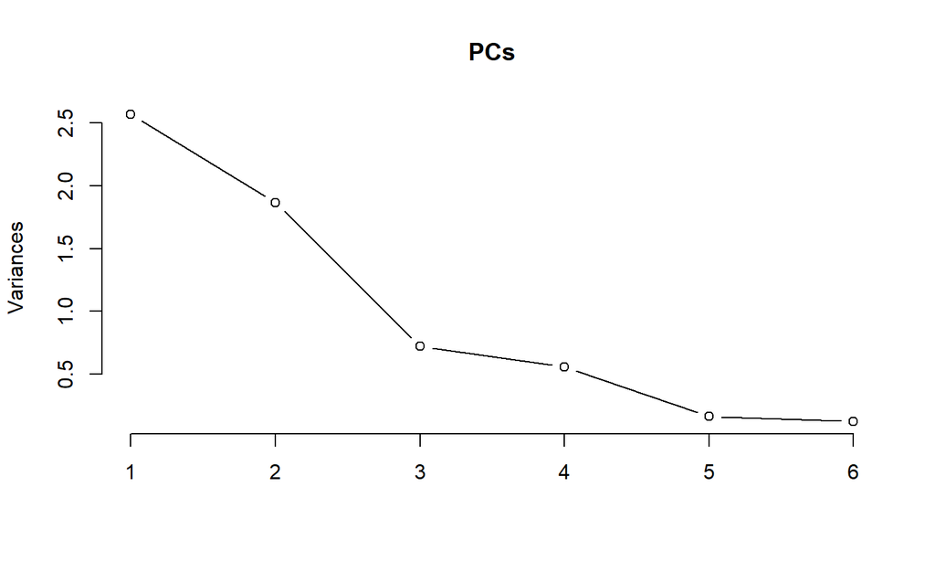

```r
screeplot(PCs, type = "lines") #scree plot used for visual
```

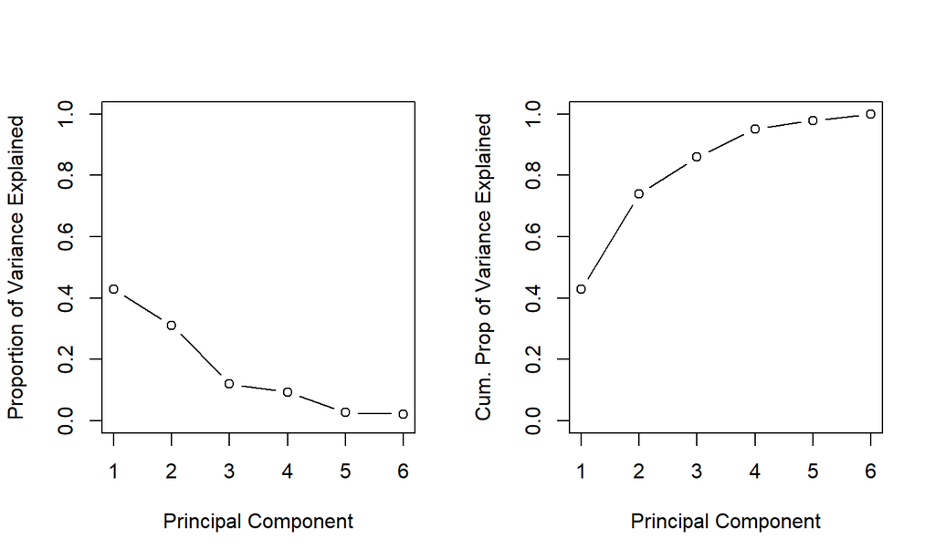

```r
par(mfrow = c(1, 2))
plot(PCs$sdev^2/sum(PCs$sdev^2), xlab = "Principal Component",
         ylab = "Proportion of Variance Explained", ylim = c(0, 1), type = 'b')
plot(cumsum(PCs$sdev^2/sum(PCs$sdev^2)), xlab = "Principal Component",
ylab = "Cum. Prop of Variance Explained", ylim = c(0, 1), type = 'b')
```

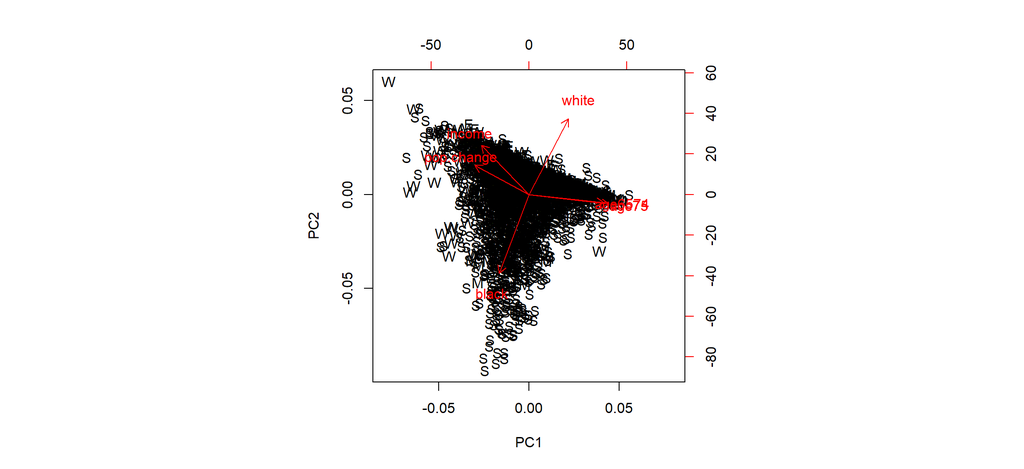

```r
biplot(PCs, xlabs = subRegionData$region, cex = 1, xlim = c(-0.08, 0.08))
```

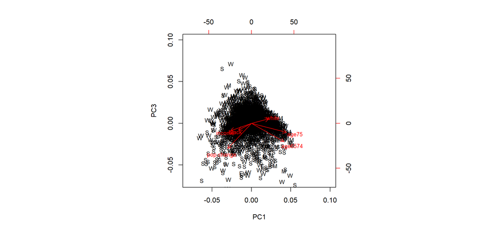

```r
biplot(PCs, xlabs = subRegionData$region, choices = c(1,3), cex = 0.8,
             xlim = c(-0.08, 0.1), ylim = c(-0.07, 0.1))
```

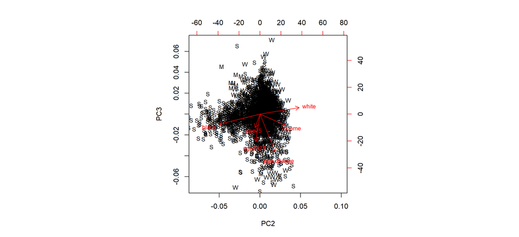

```r
biplot(PCs, xlabs = subRegionData$region, choices = 2:3, cex = 0.8,
             xlim = c(-0.08, 0.1), ylim = c(-0.07, 0.07))
```

## PCA Details

Goal: Obtain a linear combination of the variables that accounts for the largest amount of variability (location not important for variance, assume 0 mean for each predictor)

Find

\[z_{i1} = \phi_{11}x_{i1} + \phi_{21}x_{i2} + ... + \phi_{p1}x_{ip}\]

values so that the set of \(z's\) has the largest variance.

- Must constrain \(\phi\) values, else could get arbitrarily large
- Constraint: \(\sum_{j=1}^{p}\phi_{j1}^2 = 1\)

## PCA Details

Function of interest (variability is just sum of squared since mean is 0)

\[\underset{\phi's}{max}\frac{1}{n}\sum_{i=1}^{n}z_{i1}^2\mbox{ subject to } \sum_{j=1}^{p}\phi_{j1}^2 = 1\]

Once first PC found, now find next most variable linear combination

- Constraint: Must be uncorrelated with 1st PC
- Process continues until \(min(n-1, p)\) PCs are found

## PCA Details

Solving for the PCs is equivalent to doing an eigenvalue decomposition on the covariance matrix!

- Eigenvectors represent the "loadings" \(\phi's\)
  - Weight for each variables "importance" in the PC
  - Can be used to create interpretations of PCs
- Eigenvalues represent how much of the variation exists on that PC
- Largest eigenvalue (w/eigenvector) correspond to first PC

## PCA Details

SDs - the square roots of the eigenvalues of the cov/corr matrix

Rotation - the variable loadings (close to 0 –> small weight in that PC)

```r
PCs <- prcomp(subCountyData, center = TRUE, scale = TRUE)
PCs
```

```
## Standard deviations (1, .., p=6):
## [1] 1.6025670 1.3659474 0.8493128 0.7462012 0.4045648 0.3523432
##
## Rotation (n x k) = (6 x 6):
##                   PC1         PC2        PC3         PC4           PC5
## pop.change -0.3871942  0.23586385 -0.7348314  0.45628706 -0.0009506493
## age6574     0.5327883 -0.06625251 -0.5363113 -0.07452922  0.0801851487
## age75       0.5717587 -0.07693114 -0.2635841 -0.23015097 -0.2332104031
## income     -0.3401538  0.39747879 -0.2175688 -0.81778137 -0.0833688626
## white       0.2810171  0.61146690  0.1288379  0.06349392  0.7111870516
## black      -0.2112678 -0.63417608 -0.1974361 -0.24592723  0.6530275311
##                    PC6
## pop.change  0.21511141
## age6574    -0.64197601
## age75       0.70024313
## income     -0.05703581
## white       0.14394411
## black       0.16516795
```

## Recap

- Principal Components Analysis (PCA) is a dimension reduction technique
- PCA looks for *linear combinations* of \(p\) variables that accounts for as much variability as possible
- Reduces dimension of data from \(p\) to \(m\)
- Choosing \(m\) is subjective!
- Interpretation is subjective!
- Scaling is needed (most of the time) since units will vastly change results
- Can use as predictors in a regression (or other) model (PC Regression)